Shortcuts:

| Insert a code chunk | Run | Knit | -> | %>% |
| --- | --- | --- | --- | --- |
| cmd+alt+i | cmd+shift+enter | cmd+shift+k | alt+- | ctrl+shift+m |

- Load required packages

```r
library(forecast)
library(tsDyn)
library(zoo)
library(MASS)
library(reshape2)
library(reshape)
library(ggplot2)
library(dplyr)
library(gapminder)
library(smooth)
```

- Load UNRATE data from U.S. macroeconomic series, 1947–2009

```r
setwd("/Users/aubrey/Documents/GitHub/Master-s_Thesis")
unrate_data <- read.table("datasets/text_data/sim/unrate.txt", header = TRUE,
                    col.names=c("time", "unemployment"), sep=",")
head(unrate_data)
```

```
##    time unemployment
## 1 Q1-47          NaN
## 2 Q2-47          NaN
## 3 Q3-47          NaN
## 4 Q4-47          NaN
## 5 Q1-48          4.0
## 6 Q2-48          3.6
```

– Typical AR(2) model at first glance:

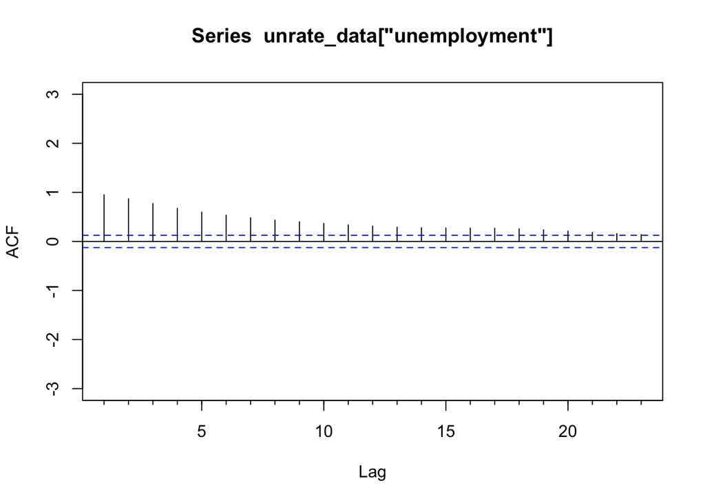

```
##
## Autocorrelations of series 'unrate_data["unemployment"]', by lag
##
##     0     1     2     3     4     5     6     7     8     9    10    11    12
## 1.000 0.951 0.870 0.772 0.675 0.598 0.536 0.483 0.436 0.401 0.367 0.337 0.313
##    13    14    15    16    17    18    19    20    21    22    23
## 0.292 0.279 0.273 0.271 0.268 0.256 0.237 0.211 0.184 0.160 0.139
```

```r
print(Acf(unrate_data["unemployment"]))
```

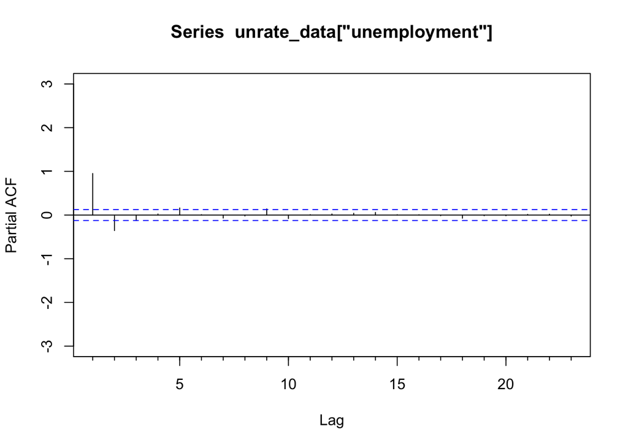

```
##
## Partial autocorrelations of series 'unrate_data["unemployment"]', by lag
##
##      1      2      3      4      5      6      7      8      9     10     11
##  0.951 -0.356 -0.124  0.025  0.162  0.008 -0.069 -0.022  0.140 -0.080  0.008
##     12     13     14     15     16     17     18     19     20     21     22
##  0.024  0.040  0.060  0.007  0.006 -0.016 -0.072 -0.016 -0.016  0.015  0.018
##     23
## -0.024
```

```r
print(Pacf(unrate_data["unemployment"]))
```

But the result of fitting auto.arima(unrate_ts_nona) points to ARIMA(1,1,2)(2,0,1)[4]

It doesn’t matter whether the model fit the data, because I aim to simulate linear time series and nonlinear time series. I only utilize the unemployment data as a base to embed more realistic informtion on the parameters. The simulated data is semi-artificial.

– Transform dataframe to time series object:

```r
# Convert "time" column to Date format
unrate_data$time <- as.Date(paste0(unrate_data$time, "-01"), format = "%b-%y-%d")

# Create a time series object
unrate_ts <- ts(unrate_data$unemployment, frequency = 4, start = c(1947, 1))

# only 1947 has nan value, delete it
unrate_ts_nona <- na.omit(unrate_ts)

# Print the transformed time series
head(unrate_ts_nona)
```

```
##      Qtr1 Qtr2 Qtr3 Qtr4
## 1948  4.0  3.6  3.8  4.0
## 1949  5.0  6.2
```

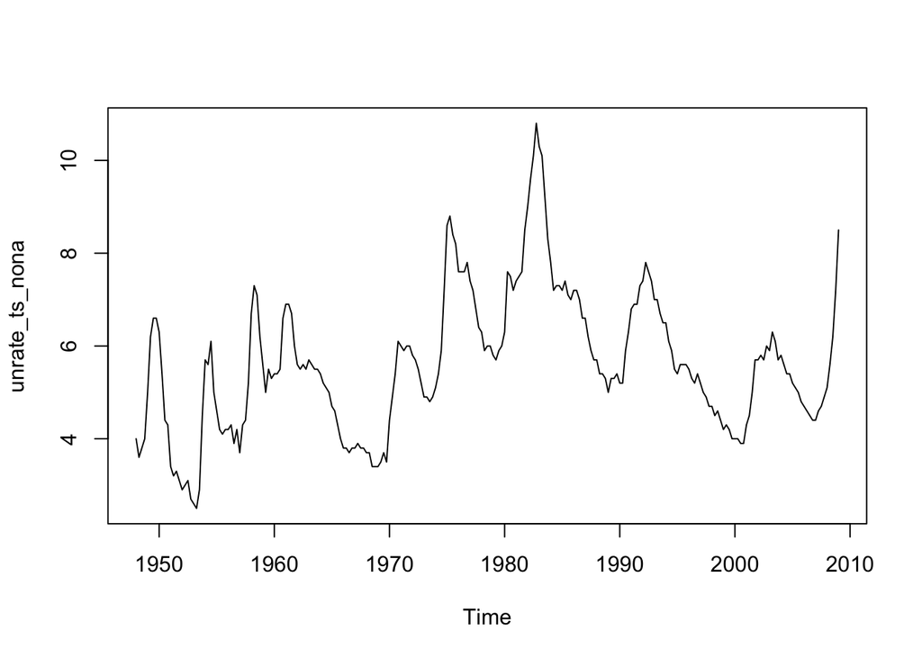

```r
plot(unrate_ts_nona)
```

- Simulation of Grecov’s paper:

```r
#
# Create an empty dataframe to store scenarios
scenario_df <- data.frame()
scenario_df_true <- data.frame()

# Define the time series lengths
time_series_lengths <- c(60, 222)
#
# Define the amounts of time series
amount_of_time_series <- c(10, 101, 500)
#
# Define the type of intervention
te_intervention <- c("ho", "he")

# Define the proportion of control and treated units
proportion_control_treated <- 0.5

# Define the DGPs (Linear and Nonlinear)
dgps <- c("l", "nl")

# Loop through scenarios
for (length in time_series_lengths) {
  for (amount in amount_of_time_series) {
    for (dgp in dgps) {
      for (te in te_intervention){
        # Fit DGP's model to the UNRATE data
        if (dgp == "l") {
                model <- auto.arima(unrate_ts_nona)
                # print(summary(model))
            } else if (dgp == "nl") {
                model <- selectSETAR(unrate_ts_nona, m=2,plot=FALSE)
                nthresh <- model$nthresh
                thDelay <- model$bests["thDelay"]
                # manually record the data
                model <- setar(unrate_ts_nona, mL=model$bests["mL"],
                               mH=model$bests["mH"],nthresh=nthresh,
                  thDelay=thDelay, th=model$bests["th"])
                # model$coefficients

                B <- model$coefficients[1:(length(model$coefficients)-1)]
                th <- model$coefficients["th"]
            }

        synthetic_data_list <- list()  # Store synthetic data for this scenario

        # Generate synthetic data for each time series in this scenario
        for (n in 1:amount) {
            # Simulate time series
            temp <- TRUE
            while(temp){
              if (dgp == "l") {
                synthetic_data <- simulate(model, nsim = length, future=F)
              } else {
                synthetic_data <- setar.sim(B=B, n=length,Thresh=th,nthresh=nthresh,
                                            thDelay=thDelay, lag=2,
                  include=model$include, setarObject=model,type="simul")
                 # starting=unrate_ts_nona[1])
                  }
              # constraints
              if((any(synthetic_data<0))||(any(synthetic_data>15))){
                temp <- TRUE
              }else{
                temp <- FALSE
              }
            }

#               # normalize to 0 mean and unit variance
#               synthetic_data <- scale(synthetic_data)
# # First, the series are normalised to zero mean and unit variance. Then, to make
# # the scenarios more realistic we make all the data non-negative by subtracting from every series its
# # smallest value if that is negative. Since according to Hyndman and Koehler (2006) the error measures
# # associated with the study such as Symmetric Mean Absolute Percentage Error (SMAPE) are prone to
# # issues with values close to zero, as the next step we add one to the whole series if the minimum value
# # is less than one.
#               min <- min(synthetic_data)
#               if (min < 0){
#                 synthetic_data <- synthetic_data - min
#               }
#               if (min < 1){
#                 synthetic_data <- synthetic_data + 1
#               }
#               synthetic_data <- t(synthetic_data)

            synthetic_data_list[[n]] <- synthetic_data
        }

        # Combine synthetic data into a single dataframe
        synthetic_data_df <- do.call(rbind, synthetic_data_list)
        #   synthetic_data_df <- cbind(c(1:amount), synthetic_data_df)

        # Divide units into control and treated
        num_control <- floor(amount * proportion_control_treated)
        control_units <- synthetic_data_df[1:num_control, ]
        treated_units <- synthetic_data_df[(num_control + 1):amount, ]

        # Introduce homogeneous or heterogeneous interventions
        ## replicate the dataframe
        # treated_units <- cbind.data.frame(rep(te_intervention, each=num_control),
        #     treated_units[rep(seq_len(nrow(treated_units)), times = 2),])

        # Intervention at T0 = 49 or 211, prediction range is 12
        # quantile_90 <- quantile(unlist(treated_units[ , (length-11):length]), 0.9)
        quantile_90 <- apply(treated_units[, (length-11):length], 2,
                             quantile, probs = 0.9)
        # Calculate the standard deviation from the treated units before intervention
        sd_before_intervention <- sd(unlist(treated_units[, 1:(length-10)]))
        treated_units_origin <- matrix(treated_units[, (length-11):length], nrow = nrow(treated_units), ncol = 12)

        if (te == "ho"){
            treated_units[ , (length-11):length][treated_units[ ,
             (length-11):length] >= quantile_90] <- treated_units[ ,
               (length-11):length][treated_units[ , (length-11):length] >=
                quantile_90] + sd_before_intervention
                # Add one sd
        }else{
            treated_units[ , (length-11):length][treated_units[ ,
             (length-11):length] > quantile_90] <- treated_units[ ,
               (length-11):length][treated_units[ , (length-11):length] >
                quantile_90] + runif(1, 0.7, 1.5) * sd_before_intervention
            # Add r * sd
        }

        # Melt the groups
        control_units_melted <- melt(control_units)
        colnames(control_units_melted) <- c("series_id", "time", "value")
        control_units_melted["c_t"] <- "control"
        treated_units_melted <- melt(treated_units)
        colnames(treated_units_melted) <- c("series_id", "time", "value")
        treated_units_melted["c_t"] <- "treated"
        treated_units_melted["series_id"] <- treated_units_melted["series_id"] + num_control
        treated_units_original_melted <- melt(treated_units_origin)
        colnames(treated_units_original_melted) <- c("series_id", "time", "value")
        treated_units_original_melted["c_t"] <- "treated"
        treated_units_original_melted["series_id"] <- treated_units_original_melted["series_id"] + num_control

        # Create a scenario row
        scenario_row <- rbind(control_units_melted, treated_units_melted)
        scenario_row["time_series_length"] <- length
        scenario_row["amount_of_time_series"] <- amount
        scenario_row["dgp"] <- dgp
        scenario_row["te_intervention"] <- te
        scenario_row["series_id"] <- with(scenario_row,
            paste0(amount_of_time_series, "_",# c_t,"_",
                series_id, "_", time_series_length, "_",
                    dgp, "_", te_intervention))
        # for true counterfactual
        scenario_row_true <- treated_units_original_melted
        scenario_row_true["time_series_length"] <- length
        scenario_row_true["amount_of_time_series"] <- amount
        scenario_row_true["dgp"] <- dgp
        scenario_row_true["te_intervention"] <- te
        scenario_row_true["series_id"] <- with(scenario_row_true,
            paste0(amount_of_time_series, "_",# c_t,"_",
                series_id, "_", time_series_length, "_",
                    dgp, "_", te_intervention))

        # Add the scenario row to the dataframe
        scenario_df <- rbind(scenario_df, scenario_row)
        scenario_df_true <- rbind(scenario_df_true, scenario_row_true)
      }

    }
  }
}
```

– Read the result from simulation

```r
# setwd("/Users/aubrey/Documents/GitHub/Master-s_Thesis")
# save scenario_df
# write.csv(scenario_df, "datasets/text_data/sim/scenario_df.csv", row.names = FALSE)
# write.csv(scenario_df_true, "datasets/text_data/sim/scenario_df_true.csv", row.names = FALSE)
scenario_df <- read.csv("/Users/aubrey/Documents/GitHub/Master-s_Thesis/datasets/text_data/sim/scenario_df.csv")
scenario_df_true <- read.csv("/Users/aubrey/Documents/GitHub/Master-s_Thesis/datasets/text_data/sim/scenario_df_true.csv")
```

```r
print(nrow(unique(scenario_df[c("time_series_length",
 "amount_of_time_series", "dgp", "te_intervention")])))
```

```
## [1] 24
```

```r
print(nrow(unique(scenario_df[c("series_id")])))
```

```
## [1] 4888
```

1. Figure2_a from the paper

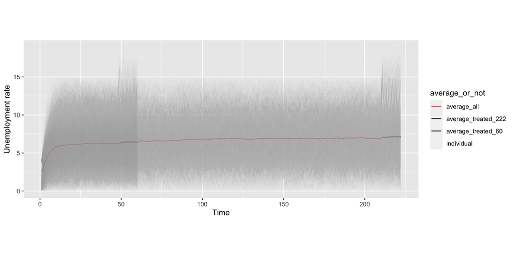

```r
# Calculate an average
example <- scenario_df
example["average_or_not"] <- "individual"

# average of all time series
example_average <- example %>%
  group_by(time) %>%
  summarize(value = mean(value))

# average of all treated time series after 49
example_average1 <- example %>%
  filter(c_t == "treated" & time_series_length == 60 & time >= 49) %>%
  group_by(time) %>%
  summarize(value = mean(value))

# average of all treated time series after 211
example_average2 <- example %>%
  filter(c_t == "treated" & time_series_length == 222 & time >= 211) %>%
  group_by(time) %>%
  summarize(value = mean(value))

bind_average <- function(a, c_t, type, time_series_length){
  a["average_or_not"] <- type
  a["c_t"] <- c_t
  a["amount_of_time_series"] <- 0
  a["time_series_length"] <- time_series_length
  a["dgp"] <- "average"
  a["te_intervention"] <- "average"
  a["series_id"] <- with(a,
              paste0(amount_of_time_series, "_",
                    time_series_length, "_",
                      dgp, "_", te_intervention))

  a <- as.data.frame(a)
  a <- a[c("series_id", "time", "value", "c_t",
  "time_series_length", "amount_of_time_series", "dgp",
    "te_intervention", "average_or_not")]
  return(a)
}

# example_add_average <- rbind(example, example_average)
example_add_average <- rbind(example, bind_average(example_average,
                         "average", "average_all", 222))
example_add_average <- rbind(example_add_average,
                          bind_average(example_average1,"treated",
                           "average_treated_60", 60))
example_add_average <- rbind(example_add_average,
                          bind_average(example_average2,"treated",
                           "average_treated_222", 222))


# Plotting
plot <- ggplot(data = example_add_average,
               aes(x = time, y = value, group = series_id)) +
  geom_line(aes(color = average_or_not, alpha = average_or_not)) +
  scale_linewidth(range = 0.01) +
  scale_color_manual(values = c(average_all = "red",
   average_treated_60 = "black", average_treated_222 = "black",
    individual = "darkgrey")) +
  scale_alpha_manual(values = c(average_all = 1,
   average_treated_60 = 1, average_treated_222 = 1,
    individual = 0.02))+
      labs(x = "Time", y = "Unemployment rate") +
          theme(aspect.ratio=2/5)
plot
```

```r
# Save the plot
# ggsave(file = paste("Figure2_a.pdf"),
#         plot = plot, width = 8, height = 5, dpi = 300)
```

2. Figure2_b part 1 from the paper

```r
# pre-intervention
pre_intervention <- quantile(scenario_df[(scenario_df$time<
  (scenario_df$time_series_length-11)),
 "value"], probs = seq(0, 1, 1/1000))
# post-intervention
post_intervention <- quantile(scenario_df[(scenario_df$c_t=="treated")&
  (scenario_df$time>=(scenario_df$time_series_length-11)) ,
 "value"], probs = seq(0, 1, 1/1000))
# true counterfactual
true_counterfactual <- quantile(scenario_df[(scenario_df$c_t=="control")&
  (scenario_df$time>=(scenario_df$time_series_length-11)) ,
 "value"], probs = seq(0, 1, 1/1000))

quantile_data <- data.frame(quantiles=as.numeric(gsub("%", "", names(pre_intervention))),
 pre_intervention=unname(pre_intervention),
  post_intervention=unname(post_intervention),
    true_counterfactual=unname(true_counterfactual),
      stringsAsFactors=FALSE)

quantile_data_melted <- melt(quantile_data, id.vars="quantiles", variable_name="type")
str(quantile_data_melted)
```

```
## 'data.frame':    3003 obs. of  3 variables:
##  $ quantiles: num  0 0.1 0.2 0.3 0.4 0.5 0.6 0.7 0.8 0.9 ...
##  $ type     : Factor w/ 3 levels "pre_intervention",..: 1 1 1 1 1 1 1 1 1 1 ...
##  $ value    : num  7.84e-05 1.30e-01 2.36e-01 3.36e-01 4.16e-01 ...
```

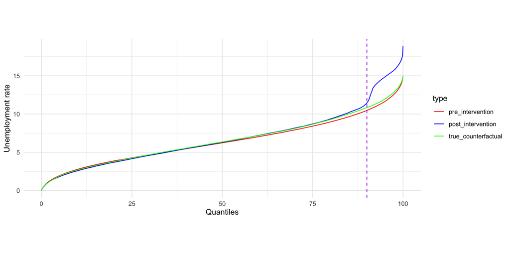

```r
quantile_plot <- ggplot(data = quantile_data_melted,
  aes(x=quantiles, y=value)) +
  geom_line(aes(color = type)) +
  scale_color_manual(values = c(pre_intervention = "red",
   post_intervention = "blue", true_counterfactual = "green"))+
   geom_vline(xintercept=90, color = "purple", linetype = "dashed")+
      labs(x = "Quantiles", y = "Unemployment rate") +
          theme_minimal() +
          theme(aspect.ratio=2/5)
quantile_plot
```

```r
# Save the plot
# ggsave(file = paste("Figure2_b_1.pdf"), plot=quantile_plot,
#          width = 8, height = 5, dpi = 300)
```

3. Figure2_b part 2 from the paper

```r
# The formular
# pre-intervention
pre_intervention_f <- quantile(scenario_df[(scenario_df$time<
  (scenario_df$time_series_length-11)),
 "value"], probs = c(0,0.05,0.1,0.2,0.3,0.4,0.5,0.6,0.7,
                0.8,0.9,0.95,1))
# post-intervention
post_intervention_f <- quantile(scenario_df[(scenario_df$c_t=="treated")&
  (scenario_df$time>=(scenario_df$time_series_length-11)) ,
 "value"], probs = c(0,0.05,0.1,0.2,0.3,0.4,0.5,0.6,0.7,
                0.8,0.9,0.95,1))
quantile_data_f <- data.frame(quantiles=names(pre_intervention_f),
 pre_intervention=unname(pre_intervention_f),
  post_intervention=unname(post_intervention_f),
    Difference=(post_intervention_f-pre_intervention_f)/pre_intervention_f*100,
      stringsAsFactors=FALSE)

quantile_data_f %>%
 mutate(across(2:4, round, digits=2))
```

```
##      quantiles pre_intervention post_intervention Difference
## 0%          0%             0.00              0.01   12170.81
## 5%          5%             1.96              1.82      -6.83
## 10%        10%             2.78              2.59      -6.86
## 20%        20%             3.87              3.69      -4.69
## 30%        30%             4.69              4.62      -1.60
## 40%        40%             5.47              5.48       0.25
## 50%        50%             6.24              6.30       1.08
## 60%        60%             7.04              7.20       2.38
## 70%        70%             7.92              8.17       3.19
## 80%        80%             8.98              9.37       4.33
## 90%        90%            10.47             11.43       9.15
## 95%        95%            11.65             14.85      27.43
## 100%      100%            15.00             18.89      25.91
```

- Simulation of Hewamalage’s paper under the similar framework like above

I only imitate MS-Hom-Short/Long from their repository: https://drive.google.com/file/d/1LDCEJzOmbmTN3wZXfKUyK8cgInbWaONM/view?usp=sharing because the I aim to create multiple time series, each is generated by the same DGP, and I only introduce homogeneous or heterogeneous effect in intervention.

```r
set.seed(1)
setwd("/Users/aubrey/Documents/GitHub/Master-s_Thesis/Simulation")
source("./ar_coefficients_generator.R")
# Create an empty dataframe to store scenarios
scenario_df2 <- data.frame()

# Define the time series lengths
time_series_lengths <- c(60, 222)

# Define the type of DGPs, first two are linear, last two are nonlinear
dgps <- c("AR(3)", "SAR(1)", "SETAR", "CLM")

# Define the amounts of time series
amount_of_time_series <- c(10, 101, 500)
#
# Define the type of intervention
te_intervention <- c("homogeneous", "heterogeneous")

# Define the proportion of control and treated units
proportion_control_treated <- 0.5

# # Define the DGPs (Linear and Nonlinear)
# dgps <- c("linear", "nonlinear")

# Loop through scenarios
for (length in time_series_lengths) {
  for (amount in amount_of_time_series) {
    for (dgp in dgps) {
      for (te in te_intervention){
        synthetic_data_list <- list()  # Store synthetic data for this scenario

        # Generate synthetic data for each time series in this scenario
        for (n in 1:amount) {
          # Simulate time series
          if (dgp == "AR(3)") {
            lags <- 3 # for AR(3) process
            maxRoot <- 5 # for a non exploding process
            # Since the DGP takes some time to reach stability in its generated
            # values, to avoid issues from initial values of the DGP,
            # a burn-in period of 100 points is cut o  from the beginning of the series.
            burn_in <- 100
            parameters <- generate_random_arma_parameters(lags, maxRoot)
            synthetic_data <- arima.sim(model=list(ar=parameters), n=length, n.start = burn_in)
            # normalize to 0 mean and unit variance
            synthetic_data <- scale(synthetic_data)
            min <- min(synthetic_data)
            if (min < 0){
              synthetic_data <- synthetic_data - min
            }
            if (min < 1){
              synthetic_data <- synthetic_data + 1
            }
            synthetic_data <- t(synthetic_data)
          }

          if (dgp == "SAR(1)"){
            # The USAccDeaths series contains the monthly totals of accidental
            # deaths in the USA for the period from the year 1973 to 1978,
            # with 72 data points
            seasonal_arima_mod <- Arima(USAccDeaths, seasonal=c(1,0,0))
            ts <- simulate(seasonal_arima_mod, nsim=length + burn_in,
              seed=(n*(n-1) + amount))
            synthetic_data <- ts[(length(ts) - length + 1) : length(ts)]
            # normalize to 0 mean and unit variance
            synthetic_data <- scale(synthetic_data)
            min <- min(synthetic_data)
            if (min < 0){
              synthetic_data <- synthetic_data - min
            }
            if (min < 1){
              synthetic_data <- synthetic_data + 1
            }
            synthetic_data <- t(synthetic_data)
          }

          if (dgp == "SETAR"){
            # use the AR coefficients and the threshold values presented
            # in the example of the tsDyn package
            # setar related variables
            lags <- 2
            no_of_thresholds <- 1
            threshold_val <- 2
            coefficient_matrix <- c(2.9,-0.4,-0.1,-1.5, 0.2,0.3)
            starting_values <- c(2.8, 2.2)
            coefficient_matrix <- coefficient_matrix + rnorm(n=1, mean=0, sd=0.007)
            synthetic_data <- setar.sim(B=coefficient_matrix, lag=lags, type="simul",
              n = length, nthresh=no_of_thresholds, Thresh=threshold_val, starting=starting_values)

            # normalize to 0 mean and unit variance
            synthetic_data <- scale(synthetic_data)
            min <- min(synthetic_data)
            if (min < 0){
              synthetic_data <- synthetic_data - min
            }
            if (min < 1){
              synthetic_data <- synthetic_data + 1
            }
            synthetic_data <- t(synthetic_data)
          }

          if (dgp == "CLM"){
            burn_in <- 40
            initial_value <- 0.5
            coefficient <- 3.6
            ts <- numeric(length + burn_in)
            ts[1] <- initial_value

            for (i in 2:(length + burn_in)){
              noise <-  rnorm(1)
              ts[i] <- max(coefficient*ts[i-1]*(1-ts[i-1]) + noise/10 , 0)
            }

            synthetic_data <- ts[(burn_in + 1):length(ts)]
          }
          synthetic_data_list[[n]] <- synthetic_data
        }

        # Combine synthetic data into a single dataframe
        synthetic_data_df <- do.call(rbind, synthetic_data_list)
        #   synthetic_data_df <- cbind(c(1:amount), synthetic_data_df)

        # Divide units into control and treated
        num_control <- floor(amount * proportion_control_treated)
        control_units <- synthetic_data_df[1:num_control, ]
        treated_units <- synthetic_data_df[(num_control + 1):amount, ]

        # Introduce homogeneous or heterogeneous interventions
        # Intervention at T0 = 49 or 211, prediction range is 12
        quantile_90 <- quantile(unlist(treated_units[ , (length-11):length]), 0.9)

        if (te == "homogeneous"){
            treated_units[ , (length-11):length][treated_units[ ,
             (length-11):length] > quantile_90] <- treated_units[ ,
               (length-11):length][treated_units[ , (length-11):length] >
                quantile_90] + sd(unlist(treated_units[ , 1:(length-10)]))
                # Add one sd
        }
        else{
            treated_units[ , (length-11):length][treated_units[ ,
             (length-11):length] > quantile_90] <- treated_units[ ,
               (length-11):length][treated_units[ , (length-11):length] >
                quantile_90] + runif(1, 0.7, 1.5) * sd(unlist(treated_units[ ,
                 1:(length-10)])) # Add r * sd
        }

        # Melt the groups
        control_units_melted <- melt(control_units)
        colnames(control_units_melted) <- c("series_id", "time", "value")
        control_units_melted["c_t"] <- "control"
        treated_units_melted <- melt(treated_units)
        colnames(treated_units_melted) <- c("series_id", "time", "value")
        treated_units_melted["c_t"] <- "treated"

        # Create a scenario row
        scenario_row <- rbind(control_units_melted, treated_units_melted)
        scenario_row["time_series_length"] <- length
        scenario_row["amount_of_time_series"] <- amount
        scenario_row["dgp"] <- dgp
        scenario_row["te_intervention"] <- te
        scenario_row["series_id"] <- with(scenario_row,
            paste0(c_t, "_", amount_of_time_series, "_",
                series_id, "_", time_series_length, "_",
                    dgp, "_", te_intervention))

        # Add the scenario row to the dataframe
        scenario_df2 <- rbind(scenario_df2, scenario_row)
      }

    }
  }
}
```

– Read the result from simulation

```r
setwd("/Users/aubrey/Documents/GitHub/Master-s_Thesis")
# save scenario_df
# write.csv(scenario_df2, "datasets/text_data/scenario_df_alternative.csv", row.names = FALSE)
scenario_df2 <- read.csv("datasets/text_data/scenario_df_alternative.csv")
```

– Check there are 48 simulated scenarios

```r
print(nrow(unique(scenario_df2[c("time_series_length",
 "amount_of_time_series", "dgp", "te_intervention")])))

print(nrow(unique(scenario_df2[c("series_id")])))
```

– Check different dgps with time_series_lengths as 60 and amount_of_time_series as 10 — AR(3)

*We use an AR(3) DGP to simulate simple linear patterns in the time series data* *We follow the procedure of Bergmeir et al. (2012) to randomly produce the 3 roots of the characteristic polynomial first and then generate the AR coefficients based on those.*

```r
plot_AR3 <- scenario_df2 %>%
  filter(amount_of_time_series == 10 &
   time_series_length == 60 & dgp == 'AR(3)')  %>%
  ggplot(aes(x = time, y = value, group = series_id)) +
  geom_line(aes(color = c_t, alpha = te_intervention)) +
  scale_color_manual(values = c("treated" = "red",
  "control" = "black")) +
  scale_alpha_manual(values = c("homogeneous" = 0.5,
   "heterogeneous" = 1)) +
   labs(title = "AR(3)",x = "Time", y = "Value") +
          theme(aspect.ratio=2/5)
plot_AR3
```

— SAR(1) *SAR DGP can simulate time series having a seasonality of a particular periodicity which are also very commonly seen in real-world scenarios.* *We first fit an SAR model of order 1 to the USAccDeaths monthly series of the datasets package (R Core Team, 2020) available in the R core libraries*

```r
plot_SAR1<- scenario_df2 %>%
  filter(amount_of_time_series == 10 &
   time_series_length == 60 & dgp == 'SAR(1)')  %>%
  ggplot(aes(x = time, y = value, group = series_id)) +
  geom_line(aes(color = c_t, alpha = te_intervention)) +
  scale_color_manual(values = c("treated" = "red",
  "control" = "black")) +
  scale_alpha_manual(values = c("homogeneous" = 0.5,
   "heterogeneous" = 1)) +
   labs(title = "SAR1",x = "Time", y = "Value") +
          theme(aspect.ratio=2/5)
plot_SAR1
```

— SETAR *The TAR model involves $k_1$ number of threshold values, which separate the space into k regimes,* *where each one is modelled by a different AR process of order p.*

*We use the AR coefficients and the threshold values presented in the example of the tsDyn package*

```r
plot_SETAR<- scenario_df2 %>%
  filter(amount_of_time_series == 10 &
   time_series_length == 60 & dgp == 'SETAR')  %>%
  ggplot(aes(x = time, y = value, group = series_id)) +
  geom_line(aes(color = c_t, alpha = te_intervention)) +
  scale_color_manual(values = c("treated" = "red",
  "control" = "black")) +
  scale_alpha_manual(values = c("homogeneous" = 0.5,
   "heterogeneous" = 1)) +
   labs(title = "SETAR",x = "Time", y = "Value") +
          theme(aspect.ratio=2/5)
plot_SETAR
```

— CLM *Chaotic Logistic Map is a zero-bounded chaotic process*

*For all homogeneous cases, we make the simulated time series difficult to model by forecasting techniques*

```r
plot_CLM<- scenario_df2 %>%
  filter(amount_of_time_series == 10 &
   time_series_length == 60 & dgp == 'CLM')  %>%
  ggplot(aes(x = time, y = value, group = series_id)) +
  geom_line(aes(color = c_t, alpha = te_intervention)) +
  scale_color_manual(values = c("treated" = "red",
  "control" = "black")) +
  scale_alpha_manual(values = c("homogeneous" = 0.5,
   "heterogeneous" = 1)) +
   labs(title = "CLM",x = "Time", y = "Value") +
          theme(aspect.ratio=2/5)
plot_CLM
```

1. Figure2_a from the paper

```r
# Calculate an average
example <- scenario_df2
example["average_or_not"] <- "individual"

# average of all time series
example_average <- example %>%
  group_by(time) %>%
  summarize(value = mean(value))

# average of all treated time series after 49
example_average1 <- example %>%
  filter(c_t == "treated" & time_series_length == 60 & time >= 49) %>%
  group_by(time) %>%
  summarize(value = mean(value))

# average of all treated time series after 211
example_average2 <- example %>%
  filter(c_t == "treated" & time_series_length == 222 & time >= 211) %>%
  group_by(time) %>%
  summarize(value = mean(value))

bind_average <- function(a, c_t, type, time_series_length){
  a["average_or_not"] <- type
  a["c_t"] <- c_t
  a["amount_of_time_series"] <- 0
  a["time_series_length"] <- time_series_length
  a["dgp"] <- "average"
  a["te_intervention"] <- "average"
  a["series_id"] <- with(a,
              paste0(c_t, "_", amount_of_time_series, "_",
                    time_series_length, "_",
                      dgp, "_", te_intervention))

  a <- as.data.frame(a)
  a <- a[c("series_id", "time", "value", "c_t",
  "time_series_length", "amount_of_time_series", "dgp",
    "te_intervention", "average_or_not")]
  return(a)
}

# example_add_average <- rbind(example, example_average)
example_add_average <- rbind(example, bind_average(example_average,
                         "average", "average_all", 222))
example_add_average <- rbind(example_add_average,
                          bind_average(example_average1,"treated",
                           "average_treated_60", 60))
example_add_average <- rbind(example_add_average,
                          bind_average(example_average2,"treated",
                           "average_treated_222", 222))


# Plotting
plot <- ggplot(data = example_add_average,
               aes(x = time, y = value, group = series_id)) +
  geom_line(aes(color = average_or_not, alpha = average_or_not)) +
  scale_linewidth(range = 0.01) +
  scale_color_manual(values = c(average_all = "red",
   average_treated_60 = "black", average_treated_222 = "black",
    individual = "darkgrey")) +
  scale_alpha_manual(values = c(average_all = 1,
   average_treated_60 = 1, average_treated_222 = 1,
    individual = 0.02))+
      labs(x = "Time", y = "Unemployment rate") +
          theme(aspect.ratio=2/5)
plot
# Save the plot
# ggsave(file = paste("Figure2_a.pdf"),
#         plot = plot, width = 8, height = 5, dpi = 300)
```

2. Figure2_b part 1 from the paper

```r
# pre-intervention
pre_intervention <- quantile(scenario_df2[(scenario_df2$time<
  (scenario_df2$time_series_length-11)),
 "value"], probs = seq(0, 1, 1/1000))
# post-intervention
post_intervention <- quantile(scenario_df2[(scenario_df2$c_t=="treated")&
  (scenario_df2$time>=(scenario_df2$time_series_length-11)) ,
 "value"], probs = seq(0, 1, 1/1000))
# true counterfactual
true_counterfactual <- quantile(scenario_df2[(scenario_df2$c_t=="control")&
  (scenario_df2$time>=(scenario_df2$time_series_length-11)) ,
 "value"], probs = seq(0, 1, 1/1000))

quantile_data <- data.frame(quantiles=as.numeric(gsub("%", "", names(pre_intervention))),
 pre_intervention=unname(pre_intervention),
  post_intervention=unname(post_intervention),
    true_counterfactual=unname(true_counterfactual),
      stringsAsFactors=FALSE)

quantile_data_melted <- melt(quantile_data, id.vars="quantiles", variable_name="type")
str(quantile_data_melted)

quantile_plot <- ggplot(data = quantile_data_melted,
  aes(x=quantiles, y=value)) +
  geom_line(aes(color = type)) +
  scale_color_manual(values = c(pre_intervention = "red",
   post_intervention = "blue", true_counterfactual = "green"))+
   geom_vline(xintercept=90, color = "purple", linetype = "dashed")+
      labs(x = "Quantiles", y = "Unemployment rate") +
          theme_minimal() +
          theme(aspect.ratio=2/5)
quantile_plot
# Save the plot
# ggsave(file = paste("Figure2_b_1.pdf"), plot=quantile_plot,
#          width = 8, height = 5, dpi = 300)
```

3. Figure2_b part 2 from the paper

```r
# The formular
# pre-intervention
pre_intervention_f <- quantile(scenario_df2[(scenario_df2$time<
  (scenario_df2$time_series_length-11)),
 "value"], probs = c(0,0.05,0.1,0.2,0.3,0.4,0.5,0.6,0.7,
                0.8,0.9,0.95,1))
# post-intervention
post_intervention_f <- quantile(scenario_df2[(scenario_df2$c_t=="treated")&
  (scenario_df2$time>=(scenario_df2$time_series_length-11)) ,
 "value"], probs = c(0,0.05,0.1,0.2,0.3,0.4,0.5,0.6,0.7,
                0.8,0.9,0.95,1))
quantile_data_f <- data.frame(quantiles=names(pre_intervention_f),
 pre_intervention=unname(pre_intervention_f),
  post_intervention=unname(post_intervention_f),
    Difference=(post_intervention_f-pre_intervention_f)/pre_intervention_f*100,
      stringsAsFactors=FALSE)

quantile_data_f %>%
 mutate(across(2:4, round, digits=2))
```